# Slow–Fast Coupling_v5: Curie–Weiss Symptoms Under Context Dynamics

We study a slow–fast hybrid system in which a fast, Ising-like (Curie–Weiss) symptom layer is coupled to a slow contextual process with feedback and noise. Simulations illustrate how slow contextual differences can drive tipping or switching-like patterns in symptoms without changing the symptom-layer coupling.

Author

Affiliation

Kyuri Park

Computational Science Lab

Published

March 11, 2026

```r
library(dplyr)
library(tidyr)
library(purrr)
library(tibble)
library(ggplot2)
library(knitr)
library(kableExtra)
library(patchwork)
library(future)
library(furrr)

# Reproducible parallel RNG
set.seed(123)
RNGkind("L'Ecuyer-CMRG")
plan(multisession, workers = max(1, parallel::detectCores() - 3))

source("../R/utils/utils_fastlayer.R")
source("../R/utils/utils_slowfast.R")
source("../R/utils/utils_plotting.R")
source("../R/utils/utils_diagnostics.R")
```

# 1. Motivation

Mental health symptoms fluctuate on fast time scales (hours–days), while socio-economic pressures (e.g., financial precarity, discrimination, workload) change more slowly (months–years). Standard symptom-network models often (i) treat symptoms as a closed system and (ii) attribute group differences in symptom dynamics to internal network differences.

Here we explicitly couple:

- a **fast 0/1 Curie–Weiss symptom layer** (binary symptoms with mean-field reinforcement),
- a **slow context variable** $P_t$ that drifts gradually,
- **feedback** from symptoms back into context,
- and (optionally) **rare jump shocks** affecting context.

[figure not shown]

We show how group differences in symptom trajectories can arise from:

- different **context baselines** $P_{\text{base}}$,
- different **regime structure** (monostable vs bistable fast layer),
- plus (optionally) **acute events** (shocks),

while keeping the **fast-layer mechanism identical within a regime**.

# 2. Fast layer: 0/1 Curie–Weiss symptom dynamics

We use spins

$$s_i \in {0,1},
\qquad
m = \frac{1}{N}\sum_i s_i \in [0,1].$$

Here $m$ is the fraction of active symptoms (a fast summary “symptom load”).

## Mean-field input (“field”)

$$H = J(m - \tfrac{1}{2}) + h_0 + \gamma_P P.$$

- $J$: within-layer coupling (symptom reinforcement).
- $h_0$: baseline bias.
- $\gamma_P$: context-to-symptom gain (how strongly $P$ shifts the layer).

## Stochastic activation rule

$$\Pr(s_i=1 \mid m, P)=\sigma(\beta H), \qquad
\sigma(x)=\frac{1}{1+e^{-x}}.$$

- $\beta$: sensitivity (sharpness of response).

## Key regime condition: bistability

For the 0/1 Curie–Weiss model, bistability occurs when:
$$\beta J > 4.$$

**Interpretation.**

- If $\beta J < 4$: one stable equilibrium $m^*(P)$ for each $P$ (smooth tracking).
- If $\beta J > 4$: two stable equilibria can coexist for a range of $P$ (low vs high symptom modes), enabling hysteresis and capture.

# 3. Slow layer: context dynamics (OU + feedback + noise + optional jumps)

We represent context as a continuous variable (P_t), updated by Euler–Maruyama:

$$P_{t+1} = P_t
+\Big[-\kappa(P_t-P_{\text{base}})+b,(m_{\text{slow},t}-m_*)\Big]dt
+\sigma_P \sqrt{dt}\epsilon_t
+\xi_t,
\qquad \epsilon_t\sim \mathcal{N}(0,1).$$

- **Mean reversion**: $-\kappa(P_t-P_{\text{base}})$
- **Feedback**: $b(m_{\text{slow},t}-m_*)$
- **Diffusion noise**: $\sigma_P\sqrt{dt}\epsilon_t$
- **Jump shocks**: $\xi_t$

## Slow symptom trace ($m_{\text{slow}}$) (what context “sees”)

We smooth fast symptom load via an exponentially weighted moving average (*EWMA*) (:

$$m_{\text{slow},t+1}=m_{\text{slow},t}+\lambda_m,(m_t-m_{\text{slow},t}).$$

Small $\lambda_m$ means context reacts to *persistent burden*, not momentary spikes.

# 4. Discrete shocks (v3 simplified jump process)

In v3 we implement **rare acute events** as an additive jump term $\xi_t$ in the context update. In discrete time, we write:

$$\xi_t = I_t A_t,$$

where $I_t\in{0,1}$ indicates whether a shock occurs during $[t,t+dt)$, and $A_t$ is the shock magnitude.

### Exogenous shocks (constant hazard)

Exogenous shocks arrive as a Poisson process with constant intensity $\lambda_{\text{exo}}$:

$$p_{\text{exo}} = 1 - e^{-\lambda_{\text{exo}}dt},\qquad
I_t^{(\text{exo})} \sim \mathrm{Bernoulli}(p_{\text{exo}}),
\qquad
A_t^{(\text{exo})} \sim \mathcal N(\mu_{\text{exo}},\sigma_{\text{exo}}^2).$$

### Endogenous shocks (hazard ramps up above a symptom threshold)

Endogenous shock intensity depends on the smoothed symptom level:

$$\lambda_{\text{endo}}(t)=\lambda_0+\lambda_1\max(0,m_{\text{slow},t}-m_{\text{crit}}),
\qquad
p_{\text{endo}}(t)=1-e^{-\lambda_{\text{endo}}(t)dt}.$$

### Both shocks with “one shock per step”

When `shock_mode="both"`, we use the total hazard

$$\lambda_{\text{tot}}(t)=\lambda_{\text{exo}}+\lambda_{\text{endo}}(t),
\qquad
p_{\text{tot}}(t)=1-e^{-\lambda_{\text{tot}}(t)dt},$$

draw **at most one shock per step**, then assign its type proportional to hazard share:

$$\Pr(\text{endo}\mid \text{shock})=\frac{\lambda_{\text{endo}}(t)}{\lambda_{\text{tot}}(t)},
\qquad
\Pr(\text{exo}\mid \text{shock})=\frac{\lambda_{\text{exo}}}{\lambda_{\text{tot}}(t)}.$$

If the shock is endogenous, draw $A_t^{(\text{endo})}\sim\mathcal N(\mu_{\text{endo}},\sigma_{\text{endo}}^2)$; otherwise draw $A_t^{(\text{exo})}\sim\mathcal N(\mu_{\text{exo}},\sigma_{\text{exo}}^2)$. The realized jump is $\xi_t=A_t^{(\cdot)}$.

**Interpretation.** Exogenous shocks represent independent life events; endogenous shocks represent “event likelihood increases when sustained burden is high,” without introducing a separate strain state (keeps the mechanism transparent and easy to tune).

# 5. Fast-layer equilibrium structure and fold thresholds

For fixed $P$, equilibria satisfy:

$$m = \sigma\left(\beta\left[J(m-\tfrac12)+h_0+\gamma_P P\right]\right).$$

We compute $m^*(P)$ across a grid of $P$ to plot a bifurcation diagram:

- **solid**: stable equilibria,
- **dashed**: unstable equilibrium (separator),
- **bistable window**: range of $P$ with two stable branches.

```r
beta_BC   <- 2.0
J_BC      <- 3.0     # beta*J = 6 (>4) => bistable-capable
h0_BC     <- 0.0
gammaP_BC <- 1.0

P_grid_BC <- seq(-2, 2, length.out = 400)
bf_BC <- cw01_bifurcation_curve(P_grid_BC, beta_BC, J_BC, h0_BC, gammaP_BC)
bif_BC <- extract_bifurcation_info(bf_BC)

cat("Bistable P-window: [",
    round(bif_BC$P_low_fold, 3), ", ",
    round(bif_BC$P_high_fold, 3), "]\n", sep="")
```

```
Bistable P-window: [-0.206, 0.206]
```

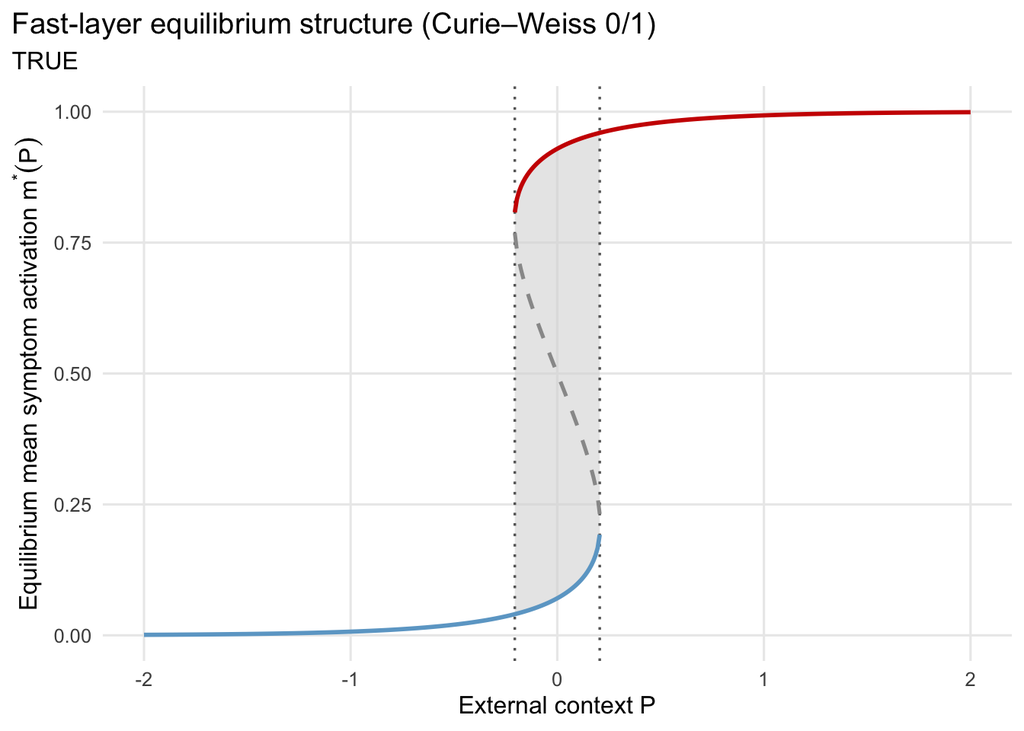

```r
plot_bifurcation_diagram(bf_BC, bif_BC,
                         title = "Fast-layer equilibrium structure (Curie–Weiss 0/1)")
```

# 6. Scenario set used in the final story

We present four scenarios:

- **A ($\beta J<4$, no shocks):** monostable fast layer → smooth tracking
- **A+Shocks ($\beta J<4$, both shocks):** shocks perturb context, but no lock-in (no competing basins)
- **B0 ($\beta J>4$, no shocks):** bistable-capable layer; feedback + diffusion can yield rare basin entry / long episodes
- **B+Shocks ($\beta J>4$, both shocks):** shocks can trigger basin entry and increase dwell time once in the high basin; episodes can occur in bursts (temporal clustering)

Within each regime (A-family vs B-family), the fast layer is held fixed; groups differ by $P_{\text{base}}$, and shocks enter only through the slow context jump increment $\Delta \xi_t$.

[output not shown]

## *Scenario A*: monostable fast layer → smooth tracking (with and without shocks)

**Goal.** Establish the control regime where the fast symptom layer has **one** stable equilibrium for each context level $P$. In this regime, changing $P_{\text{base}}$ shifts outcomes **smoothly**: there is no bistable window, no folds, and thus no basin switching in the fast layer.

**Mechanism.** When $\beta J<4$, the mean-field map
$$m=\sigma\left(\beta\left[J\left(m-\tfrac12\right)+h_0+\gamma_P P\right]\right)$$
has a **unique** stable fixed point $m^*(P)$ for every $P$. The slow context $P_t$ evolves under mean reversion + feedback + diffusion noise (and optionally jump shocks $\Delta \xi_t$), and the observed symptom load $m_t$ simply **tracks** the single curve $m^*(P)$ with finite-size / update noise.

### Scenario A (no shocks)

```r
scen_A <- list(
  name = "A",
  burn_in  = 500,
  T_steps  = 8000,
  n_rep    = 50,
  seed_base = 1000,
  groups = tibble::tibble(
    group  = c("Low baseline context", "High baseline context"),
    P_base = c(-0.8, 0.8)
  ),
  par_fast = list(
    n_nodes = 100,
    sweeps  = 40,
    beta    = 1.0,
    J       = 2.5,     # βJ = 2.5 < 4  => monostable
    h0      = 0.0,
    gammaP  = 0.4
  ),
  par_slow = list(
    dt       = 0.02,
    kappa    = 0.30,
    b        = 0.20,
    m_star   = 0.10,
    sigmaP   = 0.10,
    lambda_m = 0.001,
    shock_mode = "none"
  )
)

# res_A <- run_scenario_diagnostics_v3(
#   scenario_name = "A (βJ<4, no shocks)",
#   par_fast   = scen_A$par_fast,
#   par_slow   = scen_A$par_slow,
#   P_bases    = scen_A$groups$P_base,
#   labels     = scen_A$groups$group,
#   T_steps    = scen_A$T_steps,
#   n_rep      = scen_A$n_rep,
#   seed_base  = scen_A$seed_base,
#   burn_in    = scen_A$burn_in,
#   parallel   = TRUE
# )
#
# saveRDS(res_A, "res/res_A_v4.rds")
#res_A <- readRDS("res/res_A_v4.rds")
```

### Scenario A + shocks (v3: both exogenous + endogenous)

This variant keeps the *same* fast layer and the same OU+feedback parameters, and adds jump increments $\Delta \xi_t$ in the slow context update. The point is to show: shocks can perturb $P_t$ and create transient excursions in $m_t$, but cannot create lock-in or tipping because the fast layer still has only one basin.

```r
scen_A_both <- scen_A
scen_A_both$name <- "A+shocks"

scen_A_both$par_slow <- modifyList(scen_A$par_slow, list(
  shock_mode    = "both",

  # exogenous shocks (group-specific λ_exo set below)
  lambda_exo    = 0.0,
  shock_mu_exo  = 0.25,
  shock_sd_exo  = 0.05,

  # endogenous shocks (v3 simplified: depends directly on m_slow above m_crit)
  lambda0       = 0.00,
  lambda1       = 0.08,
  m_crit        = 0.55,
  shock_mu_endo = 0.25,
  shock_sd_endo = 0.05
))

par_slow_A_by_group <- list(
  "Low baseline context"  = modifyList(scen_A_both$par_slow, list(lambda_exo = 0.010)),
  "High baseline context" = modifyList(scen_A_both$par_slow, list(lambda_exo = 0.025))
)

# res_A_both <- run_scenario_diagnostics_v3(
#   scenario_name = "A (βJ<4, both shocks)",
#   par_fast   = scen_A$par_fast,
#   par_slow   = par_slow_A_by_group,
#   P_bases    = scen_A$groups$P_base,
#   labels     = scen_A$groups$group,
#   T_steps    = scen_A$T_steps,
#   n_rep      = scen_A$n_rep,
#   seed_base  = 12000,
#   burn_in    = scen_A$burn_in,
#   parallel   = TRUE
# )
#
# saveRDS(res_A_both, "res/res_A_both_v3.rds")
#res_A_both <- readRDS("res/res_A_both_v3.rds")
```

## *Scenario B*: bistable-capable fast layer → thresholded basin entry (with and without shocks)

**Goal.** Scenario B demonstrates what becomes possible when the fast Curie–Weiss layer is **bistable-capable** ($\beta J>4$): the system can occupy **two metastable symptom regimes** (low vs high $m$), separated by an unstable middle branch. In this regime, *small* differences in baseline context $P_{\text{base}}$, stochastic context fluctuations, and discrete shocks can determine whether a trajectory ever enters—and how long it dwells in—the high-symptom basin.

We present two variants:

- **B0 (no shocks):** bistable-capable fast layer + continuous context noise only.  
  **Point:** high-$m$ episodes can occur via **noise-driven basin entry**, depending on how close $P_{\text{base}}$ is to the fold thresholds.
- **B+S (both shocks):** same baseline configuration as B0, but with **rare jump shocks** $\Delta \xi_t$ in the context process.  
  **Point:** shocks can **trigger entry** into the high basin and **cluster** episodes by producing temporally concentrated perturbations to $P_t$.

### Mechanism (shared across B0 and B+S)

The fast layer is fixed in the bistable-capable regime:
$$m = \sigma\left(\beta\left[J\left(m-\tfrac12\right)+h_0+\gamma_P P\right]\right),$$
which can yield **two stable equilibria** $m^*_{\text{low}}(P)$ and $m^*_{\text{high}}(P)$ over an intermediate context window $[P_{\text{low fold}}, P_{\text{high fold}}]$.

The slow context evolves as OU + feedback + diffusion noise, optionally augmented by jumps:

$$P_{t+1}=P_t
+\Big[-\kappa(P_t-P_{\text{base}})+b(m_{\text{slow},t}-m_*)\Big]dt
+\sigma_P\sqrt{dt}\epsilon_t
+\Delta \xi_t.$$

In **B0**, $\Delta\xi_t\equiv 0$. In **B+S**, $\Delta\xi_t$ is a rare-jump increment (exo + endo hazards) as defined in the shocks section.

## Parameter selection (kept explicit): two-stage grid search for B0, then B+S

Because outcomes in the $\beta J>4$ regime depend strongly on how each group is positioned relative to the fold thresholds, we selected one representative parameterization using a reproducible two-stage grid search:

1. **B0 grid search (no shocks):** choose group placement + ($\kappa,b,\sigma_P$) so that
- the **high-baseline** group shows *intermediate* high-$m$ occupancy (not locked low or high), and
- the **low-baseline** group remains mostly low.
2. **B+S grid search (both shocks):** holding B0 fixed, tune shock hazards/magnitudes so that
- the **low-baseline** group exhibits **nonzero but not saturated** high-$m$ occupancy (shocks sometimes trigger basin entry),
- without pathological locking or excessive shock counts in the high-baseline group.

Reproducibility is enforced using `L'Ecuyer-CMRG` and a deterministic seed per (group, replicate).

```r
set.seed(123)
RNGkind("L'Ecuyer-CMRG")
plan(multisession, workers = max(1, parallel::detectCores() - 3))

# deterministic seed per (scenario, group, rep)
seed_for <- function(seed_base, scenario_id, group_id, rep_id){
  as.integer(seed_base + 10000L*scenario_id + 100L*group_id + rep_id)
}

# --- runner (your v3) ---
run_scenario_diagnostics_v3 <- function(
    scenario_name,
    par_fast,
    par_slow,     # list (shared) OR named list by group
    P_bases,
    labels,
    T_steps   = 6000,
    n_rep     = 3,
    seed_base = 40000,
    burn_in   = 0,
    parallel  = TRUE
){
  stopifnot(length(P_bases) == length(labels))

  get_ps <- function(label){
    if (is.list(par_slow) && !is.null(names(par_slow)) && label %in% names(par_slow)) {
      par_slow[[label]]
    } else par_slow
  }

  group_df <- tibble(group = labels, P_base = P_bases) |>
    mutate(group_id = row_number())

  tasks <- tidyr::crossing(group_df, rep_id = seq_len(n_rep)) |>
    mutate(seed = purrr::pmap_int(
      list(group_id, rep_id),
      \(g, r) seed_for(seed_base, scenario_id = 1L, group_id = g, rep_id = r)
    ))

  run_one <- function(P_base, label, group_id, rep_id, seed_i){
    ps <- get_ps(label)

    valid <- names(formals(simulate_slowfast_cw01_v3))
    ps <- ps[names(ps) %in% valid]

    dt_i <- if (!is.null(ps$dt)) ps$dt else 0.02
    ps$dt <- NULL

    fixed_names <- c("T_steps","dt","P_base","P0","m0","seed", names(par_fast))
    ps <- ps[setdiff(names(ps), fixed_names)]

    sim <- do.call(simulate_slowfast_cw01_v3, c(
      list(T_steps = T_steps, dt = dt_i, P_base = P_base, P0 = P_base, m0 = 0.05, seed = seed_i),
      par_fast,
      ps
    ))

    sim$scenario <- scenario_name
    sim$group    <- label
    sim$rep      <- rep_id
    sim$seed     <- seed_i
    sim
  }

  if (isTRUE(parallel)) {
    sim_all <- furrr::future_pmap_dfr(
      list(tasks$P_base, tasks$group, tasks$group_id, tasks$rep_id, tasks$seed),
      run_one,
      .options  = furrr::furrr_options(seed = TRUE),
      .progress = TRUE
    )
  } else {
    sim_all <- purrr::pmap_dfr(
      list(tasks$P_base, tasks$group, tasks$group_id, tasks$rep_id, tasks$seed),
      run_one
    )
  }

  metrics <- sim_all |>
    filter(t > burn_in) |>
    group_by(scenario, rep, group) |>
    summarise(
      mean_P = mean(P, na.rm = TRUE),
      mean_m = mean(m, na.rm = TRUE),
      frac_high_abs = mean(m > 0.5, na.rm = TRUE),
      n_shock = if ("shock_any" %in% names(cur_data())) sum(shock_any == 1L, na.rm = TRUE) else NA_real_,
      n_shock_exo  = if ("shock_exo" %in% names(cur_data())) sum(abs(shock_exo) > 0, na.rm = TRUE) else NA_real_,
      n_shock_endo = if ("shock_endo" %in% names(cur_data())) sum(abs(shock_endo) > 0, na.rm = TRUE) else NA_real_,
      .groups = "drop"
    )

  metrics_summary <- metrics |>
    group_by(scenario, group) |>
    summarise(
      mean_P = mean(mean_P, na.rm = TRUE),
      mean_m = mean(mean_m, na.rm = TRUE),
      frac_high_abs = mean(frac_high_abs, na.rm = TRUE),
      n_shock = mean(n_shock, na.rm = TRUE),
      n_shock_exo = mean(n_shock_exo, na.rm = TRUE),
      n_shock_endo = mean(n_shock_endo, na.rm = TRUE),
      .groups = "drop"
    )

  list(sim_all = sim_all, metrics = metrics, metrics_summary = metrics_summary)
}

# --- fast layer for B-family (βJ > 4) ---
par_fast_B <- list(
  n_nodes = 100, sweeps = 40,
  beta = 2.0, J = 3.0,        # βJ = 6 > 4
  h0 = 0.0, gammaP = 1.0
)

# --- compute folds from bifurcation curve ---
P_grid <- seq(-2, 2, length.out = 400)
bf_B   <- cw01_bifurcation_curve(P_grid, par_fast_B$beta, par_fast_B$J, par_fast_B$h0, par_fast_B$gammaP)

stab_by_P <- bf_B %>% filter(stable) %>%
  group_by(P) %>%
  summarise(n_stable = n(), m_low=min(m), m_high=max(m), .groups="drop")

bistable_window <- stab_by_P %>% filter(n_stable == 2)

P_low_fold  <- if (nrow(bistable_window)>0) min(bistable_window$P) else NA_real_
P_high_fold <- if (nrow(bistable_window)>0) max(bistable_window$P) else NA_real_

# --- placement helper (offsets from folds) ---
make_groups_B <- function(red_offset = 0.05, green_offset = 0.30){
  tibble(
    group  = c("Low baseline context", "High baseline context"),
    P_base = c(P_low_fold - green_offset, P_high_fold - red_offset)
  )
}

# --- shared slow baseline (no shocks) ---
par_slow_shared <- list(
  dt       = 0.02,
  kappa    = 0.25,
  b        = 0.25,
  m_star   = 0.25,
  sigmaP   = 0.05,
  lambda_m = 0.001
)

# ---------------------------
# Stage 1: B0 grid (no shocks)
# ---------------------------
T_steps_scan <- 6000
n_rep_scan   <- 3
burn_in_scan <- 0

grid_place <- crossing(
  green_offset = c(0.20, 0.30, 0.40),
  red_offset   = c(0.03, 0.06, 0.10)
) %>% mutate(tag = row_number())

grid_B0 <- crossing(
  sigmaP = c(0.02, 0.03, 0.04),
  kappa  = c(0.20, 0.30, 0.40),
  b      = c(0.15, 0.25, 0.35),
  m_star = c(0.25)
) %>% mutate(tag = row_number())

score_B0 <- function(ms){
  hi <- ms %>% filter(group=="High baseline context")
  lo <- ms %>% filter(group=="Low baseline context")
  if (nrow(hi)==0 || nrow(lo)==0) return(-Inf)

  red_hi   <- hi$frac_high_abs
  green_hi <- lo$frac_high_abs

  pen_red_extreme <- abs(red_hi - 0.5) * 2
  pen_green       <- 10 * green_hi

  1 - pen_red_extreme - pen_green
}

tasks_B0 <- crossing(
  place_i = seq_len(nrow(grid_place)),
  b0_i    = seq_len(nrow(grid_B0))
) %>% mutate(task_id = row_number())

run_B0_task <- function(place_i, b0_i){
  gp <- grid_place[place_i,]
  g0 <- grid_B0[b0_i,]

  groups <- make_groups_B(red_offset=gp$red_offset, green_offset=gp$green_offset)

  ps <- modifyList(par_slow_shared, list(
    sigmaP = g0$sigmaP,
    kappa  = g0$kappa,
    b      = g0$b,
    m_star = g0$m_star,
    shock_mode = "none"
  ))

  scen_id <- (place_i - 1L) * nrow(grid_B0) + b0_i
  seed_base <- 50000 + 50L * scen_id

  res <- run_scenario_diagnostics_v3(
    scenario_name = paste0("B0_place", gp$tag, "_b0", g0$tag),
    par_fast  = par_fast_B,
    par_slow  = ps,
    P_bases   = groups$P_base,
    labels    = groups$group,
    T_steps   = T_steps_scan,
    n_rep     = n_rep_scan,
    seed_base = seed_base,
    burn_in   = burn_in_scan,
    parallel  = FALSE
  )

  ms <- res$metrics_summary
  sc <- score_B0(ms)

  tibble(
    place_tag = gp$tag,
    b0_tag    = g0$tag,
    red_offset = gp$red_offset,
    green_offset = gp$green_offset,
    sigmaP = g0$sigmaP, kappa = g0$kappa, b = g0$b, m_star = g0$m_star,
    score = sc,
    red_PrHigh = ms %>% filter(group=="High baseline context") %>% pull(frac_high_abs),
    green_PrHigh = ms %>% filter(group=="Low baseline context") %>% pull(frac_high_abs)
  )
}

b0_table <- future_pmap_dfr(
  list(tasks_B0$place_i, tasks_B0$b0_i),
  run_B0_task,
  .options = furrr_options(seed = TRUE),
  .progress = TRUE
)

best_row <- b0_table %>% arrange(desc(score)) %>% slice(1)

best_groups <- make_groups_B(
  red_offset   = best_row$red_offset,
  green_offset = best_row$green_offset
)

best_ps_B0 <- modifyList(par_slow_shared, list(
  sigmaP = best_row$sigmaP,
  kappa  = best_row$kappa,
  b      = best_row$b,
  m_star = best_row$m_star,
  shock_mode = "none"
))

# ---------------------------
# Stage 2: B+S grid (both shocks)
# ---------------------------
grid_Bboth <- crossing(
  lambda_exo_lo = c(0.01, 0.02),
  lambda_exo_hi = c(0.03, 0.05),
  lambda1       = c(0.10, 0.15, 0.20),
  m_crit        = c(0.60, 0.70),
  mu            = c(0.35, 0.45, 0.60)
) %>%
  mutate(lambda0 = 0.0) %>%
  mutate(tag = row_number())

score_Bboth <- function(ms){
  hi <- ms %>% filter(group=="High baseline context")
  lo <- ms %>% filter(group=="Low baseline context")
  if (nrow(hi)==0 || nrow(lo)==0) return(-Inf)

  green_hi <- lo$frac_high_abs
  red_hi   <- hi$frac_high_abs
  red_sh   <- hi$n_shock

  pen_redlock <- 5 * pmax(0, red_hi - 0.95)
  pen_shocks  <- ifelse(is.na(red_sh), 0, 0.10 * pmax(0, red_sh - 30))

  10*green_hi - pen_redlock - pen_shocks
}

run_Bboth_task <- function(i){
  r <- grid_Bboth[i,]

  ps_lo <- modifyList(best_ps_B0, list(
    shock_mode="both",
    lambda_exo=r$lambda_exo_lo,
    lambda0=r$lambda0, lambda1=r$lambda1, m_crit=r$m_crit,
    shock_mu_exo=r$mu,  shock_sd_exo=0.15*r$mu,
    shock_mu_endo=r$mu, shock_sd_endo=0.15*r$mu
  ))
  ps_hi <- modifyList(best_ps_B0, list(
    shock_mode="both",
    lambda_exo=r$lambda_exo_hi,
    lambda0=r$lambda0, lambda1=r$lambda1, m_crit=r$m_crit,
    shock_mu_exo=r$mu,  shock_sd_exo=0.15*r$mu,
    shock_mu_endo=r$mu, shock_sd_endo=0.15*r$mu
  ))

  par_slow_by_group <- list(
    "Low baseline context"  = ps_lo,
    "High baseline context" = ps_hi
  )

  seed_base <- 70000 + 50L * i

  res <- run_scenario_diagnostics_v3(
    scenario_name = paste0("Bboth_", r$tag),
    par_fast  = par_fast_B,
    par_slow  = par_slow_by_group,
    P_bases   = best_groups$P_base,
    labels    = best_groups$group,
    T_steps   = T_steps_scan,
    n_rep     = n_rep_scan,
    seed_base = seed_base,
    burn_in   = burn_in_scan,
    parallel  = FALSE
  )

  ms <- res$metrics_summary
  sc <- score_Bboth(ms)

  tibble(
    tag = r$tag,
    score = sc,
    lambda_exo_lo = r$lambda_exo_lo,
    lambda_exo_hi = r$lambda_exo_hi,
    lambda1 = r$lambda1,
    m_crit  = r$m_crit,
    mu      = r$mu,
    green_PrHigh = ms %>% filter(group=="Low baseline context") %>% pull(frac_high_abs),
    red_PrHigh   = ms %>% filter(group=="High baseline context") %>% pull(frac_high_abs),
    red_Shocks   = ms %>% filter(group=="High baseline context") %>% pull(n_shock)
  )
}

bb_table <- future_map_dfr(
  seq_len(nrow(grid_Bboth)),
  run_Bboth_task,
  .options = furrr_options(seed = TRUE),
  .progress = TRUE
)

best_bb <- bb_table %>% arrange(desc(score)) %>% slice(1)

# save final selection for reuse
dir.create("res", showWarnings = FALSE, recursive = TRUE)
final_params <- list(
  timestamp    = Sys.time(),
  par_fast     = par_fast_B,
  best_row_B0  = best_row,
  best_groups  = best_groups,
  best_ps_B0   = best_ps_B0,
  best_bb      = best_bb
)
# saveRDS(final_params, "res/tuned/final_params.rds")
```

## Final B0 and B+S simulations (using selected parameters)

Using the selected parameter set, we simulate longer trajectories and visualize (i) time series in $P(t)$ and $m(t)$ and (ii) the trajectory projected onto the bifurcation diagram.

```r
final_params <- readRDS("../res/tuned/final_params.rds")

par_fast_B    <- final_params$par_fast
best_groups   <- final_params$best_groups
best_ps_B0    <- final_params$best_ps_B0
best_bb       <- final_params$best_bb

# helper to build B+S slow params by group
make_ps_both <- function(best_ps, best_bb_row, which_group = c("lo","hi")){
  which_group <- match.arg(which_group)
  lambda_exo <- if (which_group=="lo") best_bb_row$lambda_exo_lo else best_bb_row$lambda_exo_hi

  modifyList(best_ps, list(
    shock_mode    = "both",
    lambda_exo    = lambda_exo,
    lambda0       = 0.0,
    lambda1       = best_bb_row$lambda1,
    m_crit        = best_bb_row$m_crit,
    shock_mu_exo  = best_bb_row$mu,
    shock_sd_exo  = 0.15 * best_bb_row$mu,
    shock_mu_endo = best_bb_row$mu,
    shock_sd_endo = 0.15 * best_bb_row$mu
  ))
}


T_final    <- 8000
nrep_final <- 50
burn_final <- 500

# palette
pal <- c("Low baseline context"  = "#7ABD7D",
         "High baseline context" = "#FF5733")

# ---- B0 ----
# res_B0 <- run_scenario_diagnostics_v3(
#   scenario_name = "B0_final",
#   par_fast  = par_fast_B,
#   par_slow  = best_ps_B0,
#   P_bases   = best_groups$P_base,
#   labels    = best_groups$group,
#   T_steps   = T_final,
#   n_rep     = nrep_final,
#   seed_base = 90000,
#   burn_in   = burn_final,
#   parallel  = TRUE
# )

#res_B0 <- readRDS("res/res_B0_bestparm.rds")

# ---- B+S ----
ps_lo <- make_ps_both(best_ps_B0, best_bb, "lo")
ps_hi <- make_ps_both(best_ps_B0, best_bb, "hi")
par_slow_Bboth <- list("Low baseline context" = ps_lo,
                       "High baseline context" = ps_hi)

# res_Bboth <- run_scenario_diagnostics_v3(
#   scenario_name = "Bboth_final",
#   par_fast  = par_fast_B,
#   par_slow  = par_slow_Bboth,
#   P_bases   = best_groups$P_base,
#   labels    = best_groups$group,
#   T_steps   = T_final,
#   n_rep     = nrep_final,
#   seed_base = 91000,
#   burn_in   = burn_final,
#   parallel  = TRUE
# )

#res_Bboth <- readRDS("res/res_Bboth_bestparm.rds")
```

## Results: Scenario A vs Scenario B (representative trajectories + equilibrium overlays)

```r
# ---- palette (final plotting labels) ----
pal <- c("Low baseline context"="#7ABD7D", "High baseline context"="#FF5733")

# ---- robust relabeling: adapt if your saved objects use "Lower/Higher" ----
group_recode <- c(
  "Lower baseline context" = "Low baseline context",
  "Higher baseline context"= "High baseline context",
  "Low baseline context"   = "Low baseline context",
  "High baseline context"  = "High baseline context"
)

burnin <- 500

# ---------- load results objects ----------
res_A      <- readRDS("../res/main/res_A_clean.rds")
res_A_S    <- readRDS("../res/main/res_AS_clean.rds")
res_B0     <- readRDS("../res/main/res_B0_clean.rds")
res_B_S    <- readRDS("../res/main/res_BS_clean.rds")
```

```r
pick_representative_reps <- function(metrics_df){
  stopifnot(all(c("group","rep","mean_m") %in% names(metrics_df)))

  # If "scenario" exists, pick within (scenario, group); else just group
  grp_vars <- intersect(c("scenario","group"), names(metrics_df))

  metrics_df %>%
    group_by(across(all_of(grp_vars))) %>%
    mutate(target = mean(mean_m, na.rm = TRUE)) %>%
    slice_min(abs(mean_m - target), n = 1, with_ties = FALSE) %>%
    ungroup() %>%
    select(any_of("scenario"), group, rep)
}

get_rep_sim <- function(res_obj){
  reps <- pick_representative_reps(res_obj$metrics)

  sim_rep <- res_obj$sim_all %>%
    inner_join(reps, by = intersect(names(reps), names(res_obj$sim_all))) %>%
    mutate(group = recode(group, !!!group_recode),
           group = factor(group, levels = names(pal)))

  sim_rep
}

sim_A_rep  <- get_rep_sim(res_A)
sim_AS_rep <- get_rep_sim(res_A_S)
sim_B0_rep <- get_rep_sim(res_B0)
sim_BS_rep <- get_rep_sim(res_B_S)
```

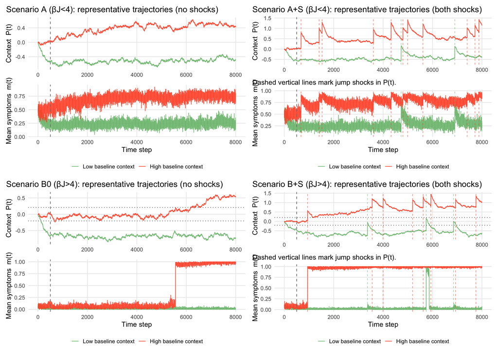

```r
p_ts_A <- plot_timeseries_with_folds(
  sim_df   = sim_A_rep,
  folds    = res_A$bif_info,
  title    = "Scenario A (βJ<4): representative trajectories (no shocks)",
  burn_in  = burnin,
  show_burn = TRUE,
  cols     = pal,
  base_size = 14
)

p_ts_AS <- plot_timeseries_with_folds(
  sim_df   = sim_AS_rep,
  folds    = res_A_S$bif_info,
  title    = "Scenario A+S (βJ<4): representative trajectories (both shocks)",
  burn_in  = burnin,
  show_burn = TRUE,
  cols     = pal,
  base_size = 14
)

p_ts_B0 <- plot_timeseries_with_folds(
  sim_df   = sim_B0_rep,
  folds    = res_B0$bif_info,
  title    = "Scenario B0 (βJ>4): representative trajectories (no shocks)",
  burn_in  = burnin,
  show_burn = TRUE,
  cols     = pal,
  base_size = 14
)

p_ts_BS <- plot_timeseries_with_folds(
  sim_df   = sim_BS_rep,
  folds    = res_B_S$bif_info,
  title    = "Scenario B+S (βJ>4): representative trajectories (both shocks)",
  burn_in  = burnin,
  show_burn = TRUE,
  cols     = pal,
  base_size = 14
)




(p_ts_A | p_ts_AS) / (p_ts_B0 | p_ts_BS) +
  plot_layout(axis_titles = "collect")
```

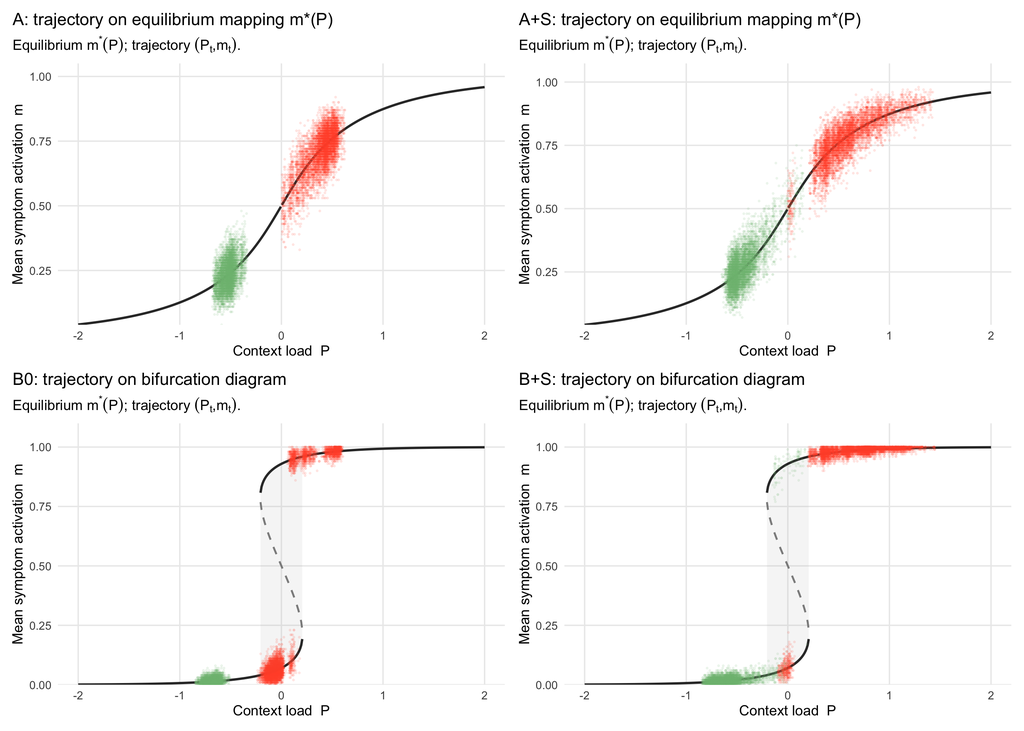

```r
# A is monostable -> usually no ribbon
p_ov_A <- plot_branch_overlay(
  bf       = res_A$bf,
  bif_info = res_A$bif_info,
  sim_df   = sim_A_rep,
  title    = "A: trajectory on equilibrium mapping m*(P)",
  burn_in  = burnin,
  cols     = pal,
  ribbon_alpha = 0.00,
  max_points_per_group = 6000,
  base_size = 14
)

p_ov_AS <- plot_branch_overlay(
  bf       = res_A_S$bf,
  bif_info = res_A_S$bif_info,
  sim_df   = sim_AS_rep,
  title    = "A+S: trajectory on equilibrium mapping m*(P)",
  burn_in  = burnin,
  cols     = pal,
  ribbon_alpha = 0.00,
  max_points_per_group = 6000,
  base_size = 14
)

# B is bistable -> keep ribbon
p_ov_B0 <- plot_branch_overlay(
  bf       = res_B0$bf,
  bif_info = res_B0$bif_info,
  sim_df   = sim_B0_rep,
  title    = "B0: trajectory on bifurcation diagram",
  burn_in  = burnin,
  cols     = pal,
  ribbon_alpha = 0.12,
  max_points_per_group = 6000,
  base_size = 14
)

p_ov_BS <- plot_branch_overlay(
  bf       = res_B_S$bf,
  bif_info = res_B_S$bif_info,
  sim_df   = sim_BS_rep,
  title    = "B+S: trajectory on bifurcation diagram",
  burn_in  = burnin,
  cols     = pal,
  ribbon_alpha = 0.12,
  max_points_per_group = 6000,
  base_size = 14
)

(p_ov_A | p_ov_AS) / (p_ov_B0 | p_ov_BS) +
  plot_layout(axis_titles = "collect")
```

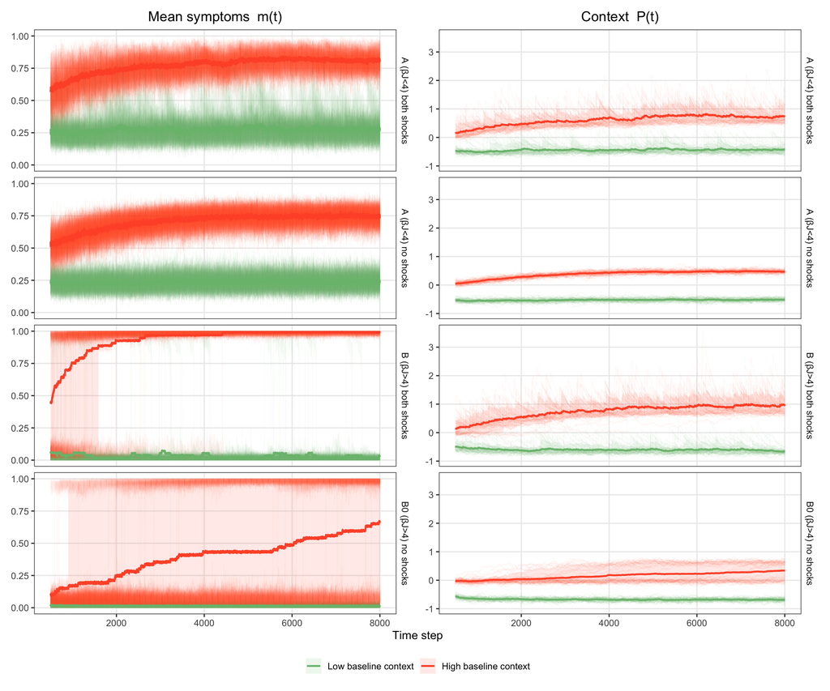

```r
extract_sim <- function(res_obj, scenario_label){
  res_obj$sim_all %>%
    select(any_of(c("t","group","rep","P","m"))) %>%
    mutate(
      scenario = scenario_label,
      group = recode(group, !!!group_recode),
      group = factor(group, levels = names(pal))
    )
}

res_list <- list(
  "A (βJ<4) no shocks"   = res_A,
  "A (βJ<4) both shocks" = res_A_S,
  "B0 (βJ>4) no shocks"  = res_B0,
  "B (βJ>4) both shocks" = res_B_S
)

sim_ens <- imap_dfr(res_list, extract_sim) %>% filter(t > burnin)

long_ens <- sim_ens %>%
  pivot_longer(c(m, P), names_to = "var_code", values_to = "value")

summ_ens <- long_ens %>%
  group_by(scenario, group, var_code, t) %>%
  summarise(
    mu  = mean(value, na.rm = TRUE),
    q10 = quantile(value, 0.10, na.rm = TRUE),
    q90 = quantile(value, 0.90, na.rm = TRUE),
    .groups = "drop"
  )

build_col <- function(var_keep = c("m","P"), ylim = NULL, title = NULL){
  var_keep <- match.arg(var_keep)

  dat  <- long_ens %>% filter(var_code == var_keep)
  summ <- summ_ens %>% filter(var_code == var_keep)

  ggplot(dat, aes(t, value, color = group)) +
    geom_ribbon(
      data = summ,
      aes(x = t, ymin = q10, ymax = q90, fill = group, group = group),
      inherit.aes = FALSE,
      alpha = 0.12
    ) +
    geom_line(aes(group = interaction(rep, group)),
              alpha = 0.06, linewidth = 0.25) +
    geom_line(data = summ, aes(y = mu, group = group),
              linewidth = 0.9) +
    facet_grid(rows = vars(scenario), scales = "fixed") +
    scale_color_manual(values = pal) +
    scale_fill_manual(values = pal) +
    labs(x = "Time step", y = NULL, title = title, color = NULL, fill = NULL) +
    theme_bw(base_size = 12) +
    theme(
      legend.position = "bottom",
      strip.background = element_blank(),
      panel.grid.minor = element_blank(),
      plot.title = element_text(hjust = 0.5)
    ) +
    { if (!is.null(ylim)) coord_cartesian(ylim = ylim) }
}

p_m <- build_col("m", ylim = c(0,1), title = "Mean symptoms  m(t)")
p_P <- build_col("P", ylim = NULL,  title = "Context  P(t)")

(p_m | p_P) + plot_layout(guides = "collect", axis_titles = "collect") &
  theme(legend.position = "bottom")
```

## Interpretation

**A (no shocks; $\beta J<4$).** The fast layer has a *single* stable equilibrium $m^*(P)$ for every context level $P$. Group differences in $P_{\text{base}}$ therefore translate into **smooth** differences in symptom means. Noise and finite-size fluctuations broaden the trajectories around the same equilibrium curve, but there is **no branch switching** because there are no competing basins.

**A+S (both shocks; $\beta J<4$).** Adding jump shocks $\Delta \xi_t$ produces **abrupt excursions** in context $P_t$, visible as synchronized perturbations in $m_t$. However, because the fast layer remains monostable, these events do **not** create hysteresis or lock-in: symptoms relax back toward the same single-valued mapping $m^*(P)$ once $P_t$ reverts.

**B0 (no shocks; $\beta J>4$).** The fast layer is bistable-capable: over a finite window of (P), there are **two** stable symptom regimes separated by an unstable middle branch. With groups positioned near the fold thresholds, diffusion noise in $P_t$ can occasionally push the high-baseline group across a fold, producing **rare basin entry** into a high-$m$ episode, while the low-baseline group remains predominantly on the low branch.

**Measures**

## What *Pr(high)*, *Switches*, and *MeanHighDur* mean

### 1) *Pr_high*

This is the **fraction of time** the system is in the *high-symptom* state.

In practice it’s computed like:

- define a binary indicator (high vs low) at each time step, typically using either:
  - **threshold**: high if $m(t) > 0.5$, OR
  - **branch assignment**: high if the point is closer to the *high stable branch* of $m^*(P)$ (your bifurcation-based labeling).

  Then

$$\text{Pr\_high} = \frac{1}{T'}\sum_{t>\text{burnin}} \mathbf{1}{ \text{high}(t)},$$
where $T'$ is the number of time steps after burn-in.

So:

- $\text{Pr\_high} \approx 0$ → almost always low symptoms
- $\text{Pr\_high} \approx 1$ → almost always high symptoms
- $\text{Pr\_high} \approx 0.5$ → spending comparable time in both (often due to switching)

### 2) *Switches*

This is the **number of times** the trajectory jumps between low and high.

If $z(t)\in{0,1}$ is your low/high label:

$$\text{Switches} = \sum_{t>\text{burnin}} \mathbf{1}{z(t)\neq z(t-1)}.$$

So:

- Switches ≈ 0 → the system stayed in one regime (low or high)
- Switches large → lots of regime changes (episodic dynamics)

### 3) *MeanHighDur*

This is the **average length of a high episode**.

Algorithmically:

1. find contiguous runs where $z(t)=1$,
2. measure each run length,
3. take the mean.

So:

- small MeanHighDur + high Switches → many short high episodes
- large MeanHighDur + low Switches → rare but persistent “stuck high” episodes

```r
library(dplyr)
library(ggplot2)
library(patchwork)

# ---- load saved grid results ----
heat_zoom <- readRDS("../res/heatmaps/heat_zoom_noshock_hyst2.rds")

# ---- sanity checks ----
req <- c("betaJ","P_base","Pr_high","Switches","MeanHighDur")
stopifnot(all(req %in% names(heat_zoom)))

# ensure numeric + ordered axes (nice tiles)
heat_zoom <- heat_zoom %>%
  mutate(
    betaJ  = as.numeric(betaJ),
    P_base = as.numeric(P_base)
  )

base_theme <- theme_bw(base_size = 12) +
  theme(
    panel.grid = element_blank(),
    legend.position = "bottom",
    plot.title.position = "plot"
  )

# ---- Heatmap 1: Pr(high) ----
p_frac <- ggplot(heat_zoom, aes(x = betaJ, y = P_base, fill = Pr_high)) +
  geom_tile() +
  geom_contour(aes(z = Pr_high), breaks = 0.5, colour = "black", linewidth = 0.4) +
  scale_fill_viridis_c(option = "C", limits = c(0,1)) +
  labs(
    title = "Occupancy of high-symptom mode",
    x = expression(beta*J),
    y = expression(P[base]),
    fill = "Pr(high)"
  ) +
  base_theme

# ---- Heatmap 2: Switch count ----
p_sw <- ggplot(heat_zoom, aes(x = betaJ, y = P_base, fill = Switches)) +
  geom_tile() +
  scale_fill_viridis_c(option = "C") +
  labs(
    title = "Switching frequency",
    x = expression(beta*J),
    y = expression(P[base]),
    fill = "Switches"
  ) +
  base_theme

# ---- Heatmap 3: Mean high duration ----
p_dur <- ggplot(heat_zoom, aes(x = betaJ, y = P_base, fill = MeanHighDur)) +
  geom_tile() +
  scale_fill_viridis_c(option = "C") +
  labs(
    title = "Mean duration of high episodes",
    x = expression(beta*J),
    y = expression(P[base]),
    fill = "Mean high\nduration"
  ) +
  base_theme

# ---- Assemble figure ----
heatmaps <- (p_frac | p_sw | p_dur) +
  plot_annotation(
    title = "Hysteresis heatmaps (no shocks): bistability and switching over (βJ, P_base)",
    subtitle = "Tiles summarize replicates; contour at Pr(high)=0.5 highlights the transition boundary."
  ) +
  plot_layout(guides = "collect") &
  theme(legend.position = "bottom")


# ggsave("img/heatmaps.pdf",heatmaps, width=10,height=5)
```